# `voice` vignette

version 0.0.0.9046

Filipe J. Zabala

2021-09-16 14:30:12

## Installation

https://github.com/filipezabala/voice

## Example 1 - Extract features

### Load packages

```r
# packs
library(voice)
library(tidyverse)
library(music)
library(gm)
```

### Set directories

```r
vaDir <- '~/Downloads/voiceAudios'
wavDir <- paste0(vaDir, '/wav')
mp3Dir <- paste0(vaDir, '/mp3')
rttmDir <- paste0(vaDir, '/rttm')
splitDir <- paste0(vaDir, '/split')
mxmlDir <- paste0(vaDir, '/musicxml')
ifelse(!dir.exists(vaDir), dir.create(vaDir), 'Directory exists!')
```

```
#> [1] "Directory exists!"
```

```r
ifelse(!dir.exists(wavDir), dir.create(wavDir), 'Directory exists!')
```

```
#> [1] "Directory exists!"
```

```r
ifelse(!dir.exists(mp3Dir), dir.create(mp3Dir), 'Directory exists!')
```

```
#> [1] "Directory exists!"
```

```r
ifelse(!dir.exists(rttmDir), dir.create(rttmDir), 'Directory exists!')
```

```
#> [1] "Directory exists!"
```

```r
ifelse(!dir.exists(splitDir), dir.create(splitDir), 'Directory exists!')
```

```
#> [1] "Directory exists!"
```

```r
ifelse(!dir.exists(mxmlDir), dir.create(mxmlDir), 'Directory exists!')
```

```
#> [1] "Directory exists!"
```

### Remove old files (¡sensible step!)

```r
cmd <- paste0('rm ', wavDir, '/*.*')
system(cmd)
```

#### >>> To do #10 [SOLVED @ 2021-09-12 VERSION 0.0.0.9044]

Automatize and test `autoDir` argument @ splitw.R.

#### >>> To do #20 [SOLVED @ 2021-09-12 VERSION 0.0.0.9044]

Parameters fromWav, fromRttm admits either file or directory @ splitw.R.

### Get audios

```r
url0 <- 'http://www.filipezabala.com/audio/bebezinho_2005.wav'
download.file(url0, paste0(wavDir, '/bebezinho_2005.wav'), mode = 'wb')
# music::playWave(paste0(wavDir, '/bebezinho_2005.wav'))
```

#### >>> To do #30

At `url0 <- 'https://github.com/filipezabala/voiceAudios/raw/main/bebezinho_2.005.wav'`, find out why the downloaded file is called `wav_bebezinho_2.005.wav`.

#### >>> To do #40

Insert a button to play audio files.

### Extract features

```r
ef <- voice::extract_features(wavDir, features = c('f0','formants','gain'),
                              round.to = 6, windowShift = 5)
```

```
#> PROGRESS 100%
#> FILE 1 OF 1 | 0.001 SECONDS
#>
#> TOTAL TIME 0.513 SECONDS
```

```r
ef
```

```
#> # A tibble: 400 × 11
#>    file_name            F0    F1    F2    F3    F4    F5    F6    F7    F8  GAIN
#>    <chr>             <dbl> <dbl> <dbl> <dbl> <dbl> <dbl> <dbl> <dbl> <dbl> <dbl>
#>  1 bebezinho_2005.w…  156.   323  1658  2940    NA  4302  5306  6257  7221  51.8
#>  2 bebezinho_2005.w…  158.   299  1843    NA  3085  4196  5262  6209  7219  48.9
#>  3 bebezinho_2005.w…  160.   297  1838  1878  3137  4111  5074  6129  7238  41.3
#>  4 bebezinho_2005.w…  159.   302  1814  2080  3135  4096  4539  6222  7268  29.7
#>  5 bebezinho_2005.w…  158.   304  1902  1964  3100  4125  4431  6255  7281  25.0
#>  6 bebezinho_2005.w…  153.   303  1660  2027  3068  4180  4267  6304  7301  25.1
#>  7 bebezinho_2005.w…  151.   300  1672  1988  3087  4051  4190  6287  7267  26.0
#>  8 bebezinho_2005.w…  148.   295  1644  1922  3100  4155    NA  6245  7187  27.0
#>  9 bebezinho_2005.w…  145.   294  1927  3101  3904  4178    NA  6221  7163  27.3
#> 10 bebezinho_2005.w…  145.   298  1937    NA  3102  4189    NA  6080  7181  26.5
#> # … with 390 more rows
```

#### >>> To do #50

Automatize and test `stereo2mono`.

#### >>> To do #60

Test different windowShift values.

## Example 2 - Smooth

#### >>> To do #70 [SOLVED @ 2021-09-12 VERSION 0.0.0.9042]

Write the function `smooth_df(x,k)`.

### Smooth

```r
odd <- seq(1,11,2)
ef_sm <- vector('list', length = length(odd))
names(ef_sm) <- paste0('k=', odd)
for(i in 1:length(ef_sm)){
  ef_sm[[i]] <- voice::smooth_df(ef, k = i)
}
```

[output not shown]

```r
sapply(ef_sm, dim)
```

```
#>      k=1 k=3 k=5 k=7 k=9 k=11
#> [1,] 400 399 398 397 396  395
#> [2,]  11  11  11  11  11   11
```

### Plot F0 smoothing

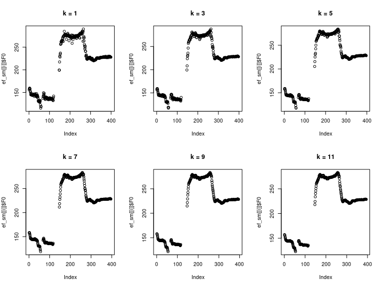

```r
par(mfrow = c(2,3))
for(i in 1:length(ef_sm)){
  plot(ef_sm[[i]]$F0, main = paste0('k = ', odd[i]))
}
```

## Example 3 - Assign notes

### Assign notes to F0

```r
for(i in 1:length(ef_sm)){
  ef_sm[[i]]$F0_spn <- voice::notes(ef_sm[[i]]$F0, measure = 'spn')
  ef_sm[[i]]$F0_midi <- voice::notes(ef_sm[[i]]$F0, measure = 'midi')
  ef_sm[[i]]$F0_octave <- voice::notes(ef_sm[[i]]$F0, measure = 'octave')
  ef_sm[[i]]$F0_black <- voice::notes(ef_sm[[i]]$F0, measure = 'black')
}
lapply(ef_sm, head)
```

```
#> $`k=1`
#> # A tibble: 6 × 15
#>   file_name      F0    F1    F2    F3    F4    F5    F6    F7    F8  GAIN F0_spn
#>   <chr>       <dbl> <dbl> <dbl> <dbl> <dbl> <dbl> <dbl> <dbl> <dbl> <dbl> <ord>
#> 1 bebezinho_…  156.   323  1658  2940    NA  4302  5306  6257  7221  51.8 D#3
#> 2 bebezinho_…  158.   299  1843    NA  3085  4196  5262  6209  7219  48.9 D#3
#> 3 bebezinho_…  160.   297  1838  1878  3137  4111  5074  6129  7238  41.3 D#3
#> 4 bebezinho_…  159.   302  1814  2080  3135  4096  4539  6222  7268  29.7 D#3
#> 5 bebezinho_…  158.   304  1902  1964  3100  4125  4431  6255  7281  25.0 D#3
#> 6 bebezinho_…  153.   303  1660  2027  3068  4180  4267  6304  7301  25.1 D#3
#> # … with 3 more variables: F0_midi <int>, F0_octave <fct>, F0_black <dbl>
#>
#> $`k=3`
#> # A tibble: 6 × 15
#>   file_name      F0    F1    F2    F3    F4    F5    F6    F7    F8  GAIN F0_spn
#>   <chr>       <dbl> <dbl> <dbl> <dbl> <dbl> <dbl> <dbl> <dbl> <dbl> <dbl> <ord>
#> 1 bebezinho_…  157.  311  1750.   NA    NA  4249  5284  6233  7220   50.3 D#3
#> 2 bebezinho_…  159.  298  1840.   NA  3111  4154. 5168  6169  7228.  45.1 D#3
#> 3 bebezinho_…  159.  300. 1826  1979  3136  4104. 4806. 6176. 7253   35.5 D#3
#> 4 bebezinho_…  158.  303  1858  2022  3118. 4110. 4485  6238. 7274.  27.4 D#3
#> 5 bebezinho_…  156.  304. 1781  1996. 3084  4152. 4349  6280. 7291   25.1 D#3
#> 6 bebezinho_…  152.  302. 1666  2008. 3078. 4116. 4228. 6296. 7284   25.6 D#3
#> # … with 3 more variables: F0_midi <int>, F0_octave <fct>, F0_black <dbl>
#>
#> $`k=5`
#> # A tibble: 6 × 15
#>   file_name      F0    F1    F2    F3    F4    F5    F6    F7    F8  GAIN F0_spn
#>   <chr>       <dbl> <dbl> <dbl> <dbl> <dbl> <dbl> <dbl> <dbl> <dbl> <dbl> <ord>
#> 1 bebezinho_…  158.  306. 1780.   NA     NA 4203  5214  6198. 7226   47.3 D#3
#> 2 bebezinho_…  159.  299. 1832.   NA   3119 4134. 4958. 6187. 7242.  40.0 D#3
#> 3 bebezinho_…  159.  301  1851. 1974   3124 4111. 4681. 6202  7262.  32.0 D#3
#> 4 bebezinho_…  157.  303  1792  2024.  3101 4134. 4412. 6260. 7283.  26.6 D#3
#> 5 bebezinho_…  154.  302. 1745. 1993   3085 4119. 4296  6282  7283   25.4 D#3
#> 6 bebezinho_…  151.  299. 1659. 1979   3085 4129.   NA  6279. 7252.  26.0 D3
#> # … with 3 more variables: F0_midi <int>, F0_octave <fct>, F0_black <dbl>
#>
#> $`k=7`
#> # A tibble: 6 × 15
#>   file_name      F0    F1    F2    F3    F4    F5    F6    F7    F8  GAIN F0_spn
#>   <chr>       <dbl> <dbl> <dbl> <dbl> <dbl> <dbl> <dbl> <dbl> <dbl> <dbl> <ord>
```

[output cut: 16 more lines]

```
#> 5 bebezinho_…  151.  299. 1761  2200. 3252. 4138.   NA  6262. 7240.  26.1 D3
#> 6 bebezinho_…  148.  298  1768    NA  3252. 4151.   NA  6227. 7220.  26.4 D3
#> # … with 3 more variables: F0_midi <int>, F0_octave <fct>, F0_black <dbl>
#>
#> $`k=11`
#> # A tibble: 6 × 15
#>   file_name      F0    F1    F2    F3    F4    F5    F6    F7    F8  GAIN F0_spn
#>   <chr>       <dbl> <dbl> <dbl> <dbl> <dbl> <dbl> <dbl> <dbl> <dbl> <dbl> <ord>
#> 1 bebezinho_…  157.  305. 1786.   NA    NA  4168. 4813. 6229. 7255.  37.0 D#3
#> 2 bebezinho_…  157.  301. 1788.   NA  3102  4126. 4627. 6234. 7262.  32.7 D#3
#> 3 bebezinho_…  155.  300. 1755  1976. 3104. 4120.   NA  6240. 7257   29.0 D#3
#> 4 bebezinho_…  152.  300. 1770. 2180. 3232. 4131.   NA  6256. 7244.  26.7 D#3
#> 5 bebezinho_…  150.  299  1790.   NA  3227. 4146.   NA  6232  7230   26.2 D3
#> 6 bebezinho_…  148.  298  1791.   NA  3227  4160.   NA  6199. 7221.  26.4 D3
#> # … with 3 more variables: F0_midi <int>, F0_octave <fct>, F0_black <dbl>
```

#### >>> To do #80 [WORK IN PROGRESS]

Write plot_note function to show both frequency and notes in spn, midi and black formats.

#### >>> To do #90

Write a function to, given a frequency in Hz, convert in any SPN.

#### >>> To do #100

Implement and study major/minor chords identifier (consider `tabr` functions).

#### >>> To do #110

Study sequences (scales and arpeggios).

## Example 4 - Duration

### Get duration

```r
dur_spn <- vector('list', length(ef_sm)); names(dur_spn) <- paste0('k=', odd)
dur_midi <- vector('list', length(ef_sm)); names(dur_midi) <- paste0('k=', odd)
dur_octave <- vector('list', length(ef_sm)); names(dur_octave) <- paste0('k=', odd)
dur_black <- vector('list', length(ef_sm)); names(dur_black) <- paste0('k=', odd)
for(i in 1:length(ef_sm)){
  dur_spn[[i]] <- voice::duration(ef_sm[[i]]$F0_spn)
  dur_midi[[i]] <- voice::duration(ef_sm[[i]]$F0_midi)
  dur_octave[[i]] <- voice::duration(ef_sm[[i]]$F0_octave)
  dur_black[[i]] <- voice::duration(ef_sm[[i]]$F0_black)
}
dur_spn[[1]]
```

```
#>    note dur_line dur_ms dur_prop
#> 1   D#3        7     35   0.0175
#> 2    D3       18     90   0.0450
#> 3   C#3        1      5   0.0025
#> 4    D3        6     30   0.0150
#> 5   C#3        2     10   0.0050
#> 6    D3        3     15   0.0075
#> 7   C#3        2     10   0.0050
#> 8    D3        2     10   0.0050
#> 9   C#3        3     15   0.0075
#> 10   C3       11     55   0.0275
#> 11   B2        1      5   0.0025
#> 12  A#2        3     15   0.0075
#> 13 <NA>        8     40   0.0200
#> 14  C#3        3     15   0.0075
```

[output cut: 52 more lines]

## Example 5 - Distance

### Distance (in semitones)

```r
nd <- vector('list', length(ef_sm))
for(i in 1:length(ef_sm)){
  nd[[i]] <- music::noteDistance(as.character(dur_spn[[i]]$note))
  print(summary(nd[[i]]))
}
```

```
#>     Min.  1st Qu.   Median     Mean  3rd Qu.     Max.     NA's
#> -1.00000 -1.00000 -1.00000 -0.03279  1.00000  2.00000        5
#>     Min.  1st Qu.   Median     Mean  3rd Qu.     Max.     NA's
#> -2.00000 -1.00000 -0.50000 -0.04762  1.00000  1.00000        5
#>    Min. 1st Qu.  Median    Mean 3rd Qu.    Max.    NA's
#> -1.0000 -1.0000 -1.0000 -0.1071  1.0000  1.0000       5
#>    Min. 1st Qu.  Median    Mean 3rd Qu.    Max.    NA's
#> -1.0000 -1.0000 -1.0000 -0.1071  1.0000  1.0000       5
#>    Min. 1st Qu.  Median    Mean 3rd Qu.    Max.    NA's
#> -1.0000 -1.0000 -1.0000 -0.1739  1.0000  1.0000       5
#>    Min. 1st Qu.  Median    Mean 3rd Qu.    Max.    NA's
#> -1.0000 -1.0000 -1.0000 -0.2105  1.0000  1.0000       5
```

```r
nd[[1]]
```

```
#>  Eb3   D3  Db3   D3  Db3   D3  Db3   D3  Db3   C3   B2  Bb2 <NA>  Db3   D3  Db3
#>    0   -1   -1    1   -1    1   -1    1   -1   -1   -1   -1   NA   NA    1   -1
#>   C3  Db3   C3  Db3   C3  Db3   C3  Db3   C3  Db3   C3  Db3 <NA>   G3   A3  Bb3
#>   -1    1   -1    1   -1    1   -1    1   -1    1   -1    1   NA   NA    2    1
#>   C4  Db4   C4  Db4   C4  Db4   C4  Db4   C4  Db4   C4  Db4   C4  Db4   C4  Db4
#>    2    1   -1    1   -1    1   -1    1   -1    1   -1    1   -1    1   -1    1
#>   C4  Db4   D4  Db4   C4  Db4   C4   B3  Bb3   A3  Bb3   A3  Bb3   A3  Bb3   A3
#>   -1    1    1   -1   -1    1   -1   -1   -1   -1    1   -1    1   -1    1   -1
#>  Bb3 <NA>
#>    1   NA
```

#### >>> To do #120

Extract and test microtones. (Giuliano’s idea.)

## Example 6 - Music sheet

### Music sheet

#### Compressing to 1%.

```r
# compress
ef_01 <- conv_df(ef, 0.01)
# assign notes
ef_01$F0_spn <- voice::notes(ef_01$F0, measure = 'spn')
# duration
nd_01 <- voice::duration(ef_01$F0_spn)
# still manual!!
li <- list('D#3','F3','C#4','A#3')
length(li)
```

```
#> [1] 4
```

```r
# gm tool
m01 <- gm::Music()
m01 <- m01 +
  # add a 4/4 time signature
  gm::Meter(4, 4) +
  # MANUALLY adding notes
  gm::Line(pitches = li,
           durations = list(1,1,1,1)) +
  # tempo
  Tempo(170)
m01
```

```
#> Music
#>
#> Line 1
#>
#> * as part 1 staff 1 voice 1
#> * of length 4
#> * of pitches D#3, F3, C#4, A#3
#> * of durations 1, 1, 1, 1
#>
#> Meter 4/4
#>
#> Tempo quarter = 170
```

```r
show(m01, to = c('score', 'audio'))
```

[figure not shown]

[interactive chart not shown]

### Smooth `k=21`.

```r
# smooth
ef_sm_21 <- voice::smooth_df(ef, k = 21)
```

```
#> * `` -> ...1
#> * `` -> ...2
#> * `` -> ...3
#> * `` -> ...4
#> * `` -> ...5
#> * ...
```

```r
# assign notes
ef_sm_21$F0_spn <- voice::notes(ef_sm_21$F0, measure = 'spn')
# duration
nd_21 <- voice::duration(ef_sm_21$F0_spn)
# still manual!!
li <- list('D3','C#3','C3',NA,'C#3',NA,'B3','C4','C#4','C4','B3','A#3','A3','A#3',NA)
length(li)
```

```
#> [1] 15
```

```r
# gm tool
m21 <- gm::Music()
m21 <- m21 +
  # add a 4/4 time signature
  gm::Meter(4, 4) +
  # MANUALLY adding notes
  gm::Line(pitches = li,
           durations = list(1,1,1,1,1,1,1,1,1,1,1,1,1,1,1)) +
  # tempo
  Tempo(999)
m21
```

```
#> Music
#>
#> Line 1
#>
#> * as part 1 staff 1 voice 1
#> * of length 15
#> * of pitches D3, C#3, C3, _, C#3, _, B3, C4, C#4, C4, B3, A#3, A3, A#3, _
#> * of durations 1, 1, 1, 1, 1, 1, 1, 1, 1, 1, 1, 1, 1, 1, 1
#>
#> Meter 4/4
#>
#> Tempo quarter = 999
```

```r
show(m21, to = c('score', 'audio'))
```

[figure not shown]

[interactive chart not shown]

#### >>> To do #130

Automate `pitches` and `durations` at `gm::Line` to capture spn/midi from `duration` data frame.

### Export musicxml file

```r
gm::export(m01, mxmlDir, 'bebezinho_01', 'musicxml')
gm::export(m21, mxmlDir, 'bebezinho_21', 'musicxml')
```

## Example 7 - Cut audios

### Get audios

```r
# font url
url0 <- 'https://github.com/filipezabala/voiceAudios/raw/main/mp3/'

# mp3 files
mp3Files <- c('anthem0.mp3', 'anthem1.mp3', 'anthem2.mp3',
              'game0.mp3', 'game1.mp3', 'game2.mp3',
              'phantom0.mp3', 'phantom1.mp3',  'phantom2.mp3',
              'romeo0.mp3', 'romeo1.mp3', 'romeo2.mp3',
              'sherlock0.mp3', 'sherlock1.mp3', 'sherlock2.mp3',
              'war0.mp3', 'war1.mp3', 'war2.mp3')

# downloading just the first mp3 file (remove [1] to download all)
for(i in mp3Files[1]){
  system(paste0('wget -r -np -k ', url0, i, ' -P ~/Downloads/voiceAudios/mp3'))
}

# tidying up files and directories
system('cp ~/Downloads/voiceAudios/mp3/github.com/filipezabala/voiceAudios/raw/main/mp3/*.* ~/Downloads/voiceAudios/mp3')
system('rm -rf ~/Downloads/voiceAudios/mp3/github.com/')
```

### Remove old files

```r
cmd <- paste0('rm ', wavDir, '/*.*')
system(cmd)
```

### Convert mp3 to wav

```r
cmd <- 'cd ~/Downloads/voiceAudios/mp3;
for i in *.[Mm][Pp]3; do ffmpeg -i "$i" "../wav/${i%.*}.wav"; done'
system(cmd)
```

#### >>> To do #140

Automatize and test mp32wav.

#### >>> To do #150

Test the hypotheses  
H1: multiple mp32wav2mp32wav… conversions reduce the audio quality.  
H2: What is the impact in the decision using  
i. original wav  
ii. original mp3 (that must be converted to wav)  
iii. H1, if H1 is consistent

### Poetry

The best words in their best order. Takes around the audio time at 8CPU and the double of the audio time at 4CPU.

```r
voice::poetry(wavDir, pycall = '/home/linuxbrew/.linuxbrew/bin/python3.9') # Linux
```

```
#> Time difference of 24.90145 secs
```

```r
# voice::poetry(wavDir, to = rttmDir, pycall = '~/miniconda3/envs/pyvoice38/bin/python3.8') # Mac
```

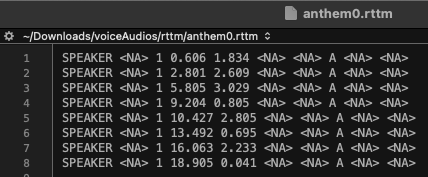

#### >>> To do #160 [WORK IN PROGRESS]

Automate speaker recognition (who speaks when?) @ poetry.R.

### Split wave

```r
# split wave
ini <- Sys.time()
voice::splitw(wavDir, fromRttm = rttmDir, to = splitDir)
Sys.time()-ini
```

```
#> Time difference of 0.1140707 secs
```

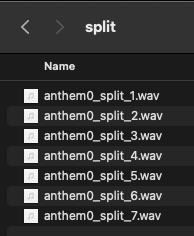

#### >>> To do #170 [SOLVED @ 2021-08-16 VERSION 0.0.0.35]

Automate argument `compact.to` at `voice::conv_df`.

#### >>> To do #180 [TESTED: NOT OK WITH GAIN]

No gain testing weighting F0 considering GAIN and other features at `voice::conv_df`. [TEST1] No gain testing weighting F0 considering GAIN.

#### >>> To do #190

Test ZCR to infer BPM.

#### >>> To do #200

Embed `gm::show` function at MacOS. Must solve: - Error in magick_image_write(image, format, quality, depth, density, comment, : rsession: NegativeOrZeroImageSize `’ @ error/image.c/CloneImage/794

#### >>> To do #210

Find the ‘best’ set of variables in different contexts.

#### >>> To do #220 [SOLVED @ Version 0.0.0.9041 2021-09-10]

Standardize `silence.gap` argument at `voice::splitw` considering NIST (National Institute of Standards and Technology).

## Glossary

. [WORK IN PROGRESS] As it says, support is welcome.  
. [SOLVED @ ‘%Y-%m-%d’ VERSION major.minor.subminor].  
. [TESTED] During the tests no gain were obtained.

```r
Sys.time()-ini0
```

```
#> Time difference of 38.55474 secs
```